# OSMI Analysis Demographics Markdown

Ryan Chiu

2024-01-16

# Introduction

This R Markdown document is intended to demonstrate to shareholders how the OSMI Mental Health Dataset was analyzed to obtain the findings and graphs presented in the analysis. The document guides readers through the entire data analysis process, from cleaning data to the plotting of variables.

# 1. Data Cleaning

## 1.1 Setup

First, the relevant libraries need to be loaded for use later on. Key libraries include “readr” (to read CSV files), “tidyverse” (to clean data), and “ggplot2” (to visualize data).

```r
library(tidyr)
library(tidyverse)
library(readr)
library(ggplot2)
library(dplyr)
library(janitor)
library(gridExtra)
```

## 1.2 Loading Data into RStudio

We can now load in the CSV file and view the survey data that was gathered by OSMI

```r
osmi_2022 <- read_csv("OSMI_2022.csv")
head(osmi_2022)
```

```
## # A tibble: 6 × 124
##   `#`       *Are you self-employ…¹ How many employees d…² Is your employer pri…³
##   <chr>                      <dbl> <chr>                                   <dbl>
## 1 eu6sxt9r…                      0 26-100                                      1
## 2 mqgsjpmc…                      0 500-1000                                    1
## 3 fkuijv5h…                      0 100-500                                     1
## 4 eb7i5ye6…                      1 <NA>                                       NA
## 5 0qoaw3bb…                      0 More than 1000                              0
## 6 3fe3pwov…                      0 25-Jun                                      1
## # ℹ abbreviated names: ¹`*Are you self-employed?*`,
## #   ²`How many employees does your company or organization have?`,
## #   ³`Is your employer primarily a tech company/organization?`
## # ℹ 120 more variables:
## #   `Is your primary role within your company related to tech/IT?` <dbl>,
## #   `Does your employer provide mental health benefits as part of healthcare coverage?` <chr>,
## #   `Do you know the options for mental health care available under your employer-provided health coverage?` <chr>, …
```

As we can see, the column names appear to be the survey questions as well as some variables related to the survey itself (e.g., unique participant ID numbers). We can now proceed with cleaning the data table

## 1.3 Cleaning Data Table

The first issue in cleaning up the data table is to rename the column names such that they are more descriptive and concise compared to just the survey question itself. Here, I have used snake-case names with enough descriptive features to get a sense of what the original questions are; a more structured method would be to use alphanumeric identifiers instead (e.g., Q1, Q2, etc.) and to link those identifiers to the actual survey questions in a separate document. Such an approach would probably be most ideal when collaborating with colleagues on the same document.

```r
colnames(osmi_2022) <- c("id", "self_employed", "company_size",
                         "tech_company", "tech_role_primary", "mh_coverage",
                         "mh_options_aware", "mh_employer_discuss", "mh_resource_employer_offer",
                         "anon_protect", "mh_leave_difficulty", "mh_ph_discuss_coworker",
                         "comfort_supervisor", "mh_employer_discuss_personal",
                         "description_mh_employer_discuss_personal",
                         "comfort_coworker", "mh_coworker_discuss_personal",
                         "description_mh_coworker_discuss_personal",
                         "mh_coworker_discuss_personal_2", "description_mh_coworker_discuss_personal_2",
                         "ph_employer_importance",
                         "mh_employer_importance", "mh_personal_coverage", "mh_resource_aware",
                         "mh_reveal_client", "mh_reveal_client_outcome", "mh_reveal_coworkers",
                         "mh_reveal_coworkers_outcome", "mh_productivity", "mh_productivity_worktime",
                         "prev_employer", "prev_employer_tech_company", "mh_coverage_prev_employer",
                         "mh_options_aware_prev_employer", "mh_prev_employer_discuss",
                         "mh_resource_prev_employer_offer",
                         "anon_protect_prev_employer", "comfort_prev_employer", "comfort_prev_supervisor",
                         "mh_prev_employer_discuss_personal", "description_mh_prev_employer_discuss_personal",
                         "comfort_prev_coworker",
                         "mh_prev_coworker_discuss_personal", "description_mh_prev_coworker_discuss_personal",
                         "mh_prev_coworker_discuss_personal_2",
                         "description_mh_prev_coworker_discuss_personal_2", "ph_prev_employer_importance",
                         "mh_prev_employer_importance",
                         "mh_current_diag", "mh_diag_history","diag_anxiety_disorder",
                         "diag_mood_disorder", "diag_psychotic_disorder", "diag_eating_disorder",
                         "diag_adhd_disorder", "diag_personality_disorder", "diag_ocd_disorder",
                         "diag_ptsd_disorder", "diag_stress_disorder", "diag_did_disorder",
                         "diag_sud_disorder", "diag_addiction_disorder", "diag_other_disorder",
                         "possible_anxiety_disorder", "possible_mood_disorder", "possible_psychotic_disorder",
                         "possible_eating_disorder", "possible_adhd_disorder", "possible_personality_disorder",
                         "possible_ocd_disorder", "possible_ptsd_disorder", "possible_stress_disorder",
                         "possible_did_disorder","possible_sud_disorder", "possible_addiction_disorder",
                         "possible_other_disorder", "past_anxiety_disorder", "past_mood_disorder",
                         "past_psychotic_disorder", "past_eating_disorder", "past_adhd_disorder",
                         "past_personality_disorder", "past_ocd_disorder", "past_ptsd_disorder",
                         "past_stress_disorder", "past_did_disorder", "past_sud_disorder",
                         "past_addiction_disorder", "past_other_disorder", "mh_past_diag",
                         "mh_disorder_treat","mh_fam_hist", "mh_work_disrupt_treated",
                         "mh_work_disrupt_untreated", "mh_other_discuss_bad_reveal", "mh_diag_share_fam_friends",
                         "ph_discuss_potential_employer", "ph_discuss_potential_employer_why",
                         "mh_discuss_potential_employer",
                         "mh_discuss_potential_employer_why", "mh_openid", "mh_openid_outcome",
                         "mh_openid_outcome_description", "mh_perceived_rx", "mh_observe_bad_rx",
                         "mh_observe_bad_rx_description", "mh_observe_good_rx", "mh_observe_good_rx_description",
                         "mh_perceived_industry_support", "mh_industry_support_suggestion", "add_comments",
                         "follow_up", "age", "gender",
                         "country_res", "us_state_res", "race",
                         "race_other", "country_work", "us_state_work",
                         "covid_diag", "start_date", "submit_date",
                         "network_id")
```

Some of the questions were repeated several times intentionally. For example, the questions “If possibly, what disorders do you believe you have?” and “If so, what disorders were you diagnosed with?” asks whether the participant believes they currently have a mental disorder and whether their clinical diagnosis history respectively. Additionally, the answers to those questions were listed as their own columns in the CSV file. As the dataset does not clarify the context of such questions, I used the [OSMI’s basic report](https://osmi.typeform.com/report/Fja7Jb9K/t5F4sKEyeGhGgU7V) of the data to figure out which of the column names were related to which questions.

The next step is to filter out any columns that are not necessary for any of the data analysis, such as the participant identifiers, network ID numbers, and survey date.

```r
osmi_select <- osmi_2022 %>%
  select(-id, -follow_up, -start_date,
         -submit_date, -network_id)
```

As mentioned previously, some of the questions’ answers were their own columns. Therefore, we placed all those columns together into a single column representing the actual question being asked by using the *unite* function. By setting the *na.rm* argument as true, we are able to eliminate any blank spaces (indicating the participant did not select that answer).

```r
osmi_unite <- osmi_select %>%
  unite("diag_disorder", diag_anxiety_disorder,
        diag_mood_disorder, diag_psychotic_disorder, diag_eating_disorder,
        diag_adhd_disorder, diag_personality_disorder, diag_ocd_disorder,
        diag_ptsd_disorder, diag_stress_disorder, diag_did_disorder,
        diag_sud_disorder, diag_addiction_disorder, diag_other_disorder,
        sep = "", na.rm = TRUE) %>%
  unite("possible_disorder",  possible_anxiety_disorder, possible_mood_disorder, possible_psychotic_disorder,
        possible_eating_disorder, possible_adhd_disorder, possible_personality_disorder,
        possible_ocd_disorder, possible_ptsd_disorder, possible_stress_disorder,
        possible_did_disorder,possible_sud_disorder, possible_addiction_disorder,
        possible_other_disorder, sep = "", na.rm = TRUE) %>%
  unite("past_disorder", past_anxiety_disorder, past_mood_disorder,
        past_psychotic_disorder, past_eating_disorder, past_adhd_disorder,
        past_personality_disorder, past_ocd_disorder, past_ptsd_disorder,
        past_stress_disorder, past_did_disorder, past_sud_disorder,
        past_addiction_disorder, past_other_disorder, sep = "", na.rm = TRUE) %>%
  unite("race", race, race_other, na.rm = TRUE)
```

A concern regarding the dataset was the possibility of having in the data in incorrect data types. To check this, we used the *str* function (for conciseness, we limited the output here to the first 6 rows).

```r
str(osmi_unite, list.len = 6)
```

```
## tibble [131 × 82] (S3: tbl_df/tbl/data.frame)
##  $ self_employed                                  : num [1:131] 0 0 0 1 0 0 0 0 0 1 ...
##  $ company_size                                   : chr [1:131] "26-100" "500-1000" "100-500" NA ...
##  $ tech_company                                   : num [1:131] 1 1 1 NA 0 1 1 0 1 NA ...
##  $ tech_role_primary                              : num [1:131] 1 1 1 NA 1 1 1 1 1 NA ...
##  $ mh_coverage                                    : chr [1:131] "I don't know" "Yes" "Yes" NA ...
##  $ mh_options_aware                               : chr [1:131] "No" "No" "Yes" NA ...
##   [list output truncated]
```

Some of the variables clearly were in the incorrect data type. For example, the variable “tech_company” is a binary yes/no question in which the participant indicates whether their company is predominantly a tech company, making it more suitable as a boolean/logical data type. Thus, we converted the data types of these columns into their appropriate formats.

```r
osmi_str <- osmi_unite %>%
  mutate(self_employed = as.logical(self_employed),
         tech_company = as.logical(tech_company),
         tech_role_primary = as.logical(tech_role_primary),
         mh_employer_discuss_personal = as.logical(mh_employer_discuss_personal),
         mh_coworker_discuss_personal = as.logical(mh_coworker_discuss_personal),
         mh_coworker_discuss_personal_2 = as.logical(mh_coworker_discuss_personal_2),
         mh_personal_coverage = as.logical(mh_personal_coverage),
         prev_employer = as.logical(prev_employer),
         prev_employer_tech_company = as.logical(prev_employer_tech_company),
         mh_prev_employer_discuss_personal = as.logical(mh_prev_employer_discuss_personal),
         mh_prev_coworker_discuss_personal = as.logical(mh_prev_coworker_discuss_personal),
         mh_prev_coworker_discuss_personal_2 = as.logical(mh_prev_coworker_discuss_personal_2),
         mh_disorder_treat = as.logical(mh_disorder_treat),
         mh_openid = as.logical(mh_openid),
         mh_openid_outcome = as.logical(mh_openid_outcome),
         mh_observe_good_rx_description = as.character(mh_observe_good_rx_description))
str(osmi_str, list.len = 6)
```

```
## tibble [131 × 82] (S3: tbl_df/tbl/data.frame)
##  $ self_employed                                  : logi [1:131] FALSE FALSE FALSE TRUE FALSE FALSE ...
##  $ company_size                                   : chr [1:131] "26-100" "500-1000" "100-500" NA ...
##  $ tech_company                                   : logi [1:131] TRUE TRUE TRUE NA FALSE TRUE ...
##  $ tech_role_primary                              : logi [1:131] TRUE TRUE TRUE NA TRUE TRUE ...
##  $ mh_coverage                                    : chr [1:131] "I don't know" "Yes" "Yes" NA ...
##  $ mh_options_aware                               : chr [1:131] "No" "No" "Yes" NA ...
##   [list output truncated]
```

Notice how tech_company is now a logical variable, verifying that the format of the data has been changed correctly.

Upon viewing the dataset at this point, we noticed that there were 2 variables, “country_work” (country participant works in) and “country_res” (country participant resides in), that are similar to each other. To determine whether any participants had a country of work that was not the same as their country of residence we utilized a *filter* function.

```r
osmi_work_res_diff <- osmi_str %>%
  select(country_res, country_work) %>%
  filter(country_res != country_work)
osmi_work_res_diff
```

```
## # A tibble: 3 × 2
##   country_res           country_work
##   <chr>                 <chr>
## 1 Macedonia             Slovenia
## 2 Sao Tome and Principe Germany
## 3 Pakistan              Switzerland
```

We noticed that there are 3 participants whose work country was not the same as their country of residence. However, since this analysis was restricted to participants within America, we can ignore these observations as they will not be included regardless. On a related note, we can proceed with filtering out the dataset to contain only American respondents.

```r
osmi_us <- osmi_str %>%
  filter(country_res == "United States of America",
         tech_company == TRUE)
head(osmi_us)
```

```
## # A tibble: 6 × 82
##   self_employed company_size   tech_company tech_role_primary mh_coverage
##   <lgl>         <chr>          <lgl>        <lgl>             <chr>
## 1 FALSE         26-100         TRUE         TRUE              I don't know
## 2 FALSE         25-Jun         TRUE         TRUE              No
## 3 FALSE         More than 1000 TRUE         TRUE              No
## 4 FALSE         100-500        TRUE         TRUE              Yes
## 5 FALSE         More than 1000 TRUE         TRUE              I don't know
## 6 FALSE         26-100         TRUE         TRUE              No
## # ℹ 77 more variables: mh_options_aware <chr>, mh_employer_discuss <chr>,
## #   mh_resource_employer_offer <chr>, anon_protect <chr>,
## #   mh_leave_difficulty <chr>, mh_ph_discuss_coworker <chr>,
## #   comfort_supervisor <chr>, mh_employer_discuss_personal <lgl>,
## #   description_mh_employer_discuss_personal <chr>, comfort_coworker <chr>,
## #   mh_coworker_discuss_personal <lgl>,
## #   description_mh_coworker_discuss_personal <chr>, …
```

At this point, a significant portion of the data table has been cleaned, and we can now proceed with the analysis and visualization of data. Some of the columns require further cleaning, but due to the exploratory nature of the analysis, not all variables will be used; therefore, we decided to clean the individual columns somewhat simultaneously with the analysis to prevent unnecessary cleaning of unused variables and improve efficiency.

# 2. Demographic Statistics

## 2.1 Creating Data Subset

The most intuitive starting point for a data analysis, particularly in healthcare research, is to examine the demographic characteristics of the sample. We can first create a subset of the data that only includes demograhpic variables for a more manageable and relevant data table. We can use the *select* function to only include our variables of interest.

```r
osmi_demo <- osmi_us %>%
  select("self_employed", "company_size", "tech_company",
         "tech_role_primary", "age", "gender",
         "us_state_res", "race",
         "us_state_work", "covid_diag")
head(osmi_demo)
```

```
## # A tibble: 6 × 10
##   self_employed company_size   tech_company tech_role_primary   age gender
##   <lgl>         <chr>          <lgl>        <lgl>             <dbl> <chr>
## 1 FALSE         26-100         TRUE         TRUE                 28 Female
## 2 FALSE         25-Jun         TRUE         TRUE                 30 Female
## 3 FALSE         More than 1000 TRUE         TRUE                 34 female
## 4 FALSE         100-500        TRUE         TRUE                 42 afab non-bi…
## 5 FALSE         More than 1000 TRUE         TRUE                 27 Female
## 6 FALSE         26-100         TRUE         TRUE                 36 Male
## # ℹ 4 more variables: us_state_res <chr>, race <chr>, us_state_work <chr>,
## #   covid_diag <lgl>
```

With our subset created, we can now proceed with analysis and visualization of the relevant demographic variables.

## 2.2 Plotting Demographic Statistics

### 2.2.1 Exclusion of Demographic Variables

Upon viewing the **osmi_demo** subset, two observations were made. First, the “covid_diag” variable had virtually no responses from the American particiapnts, rendering it impossible to analyze. Second, much like the issue earlier regarding “country_work” and “country_res”, the variables “us_state_res” (state of residence) and “us_state_work” (state of work) are far too similar to warrant separate analyses. Therefore, we decided to use the participant’s state of residence for demographic analyses. In summary, we removed “covid_diag” and “us_state_work” variables from further analyses.

### 2.2.2 Plotting Self-Employed Status

We can use the *ggplot* package to visualize the data given. In the case of self-employed status, we can use the *ggplot* function to create a graph for the variable of interest. By setting “self_employed” to the *fill* argument, we are able to create a stacked column graph, with which we can add the *coord_polar* function to convert it into a pie chart. We can also use the *after_stat* function, we can convert the counts of each unique response (i.e., zeroes, ones indicating no or yes respectively) into a percentage, as well as combining this with the *paste0* function inside the *geom_text* function to create percentage labels. Lastly, we used *scale_fill_discrete* to relabel the numeric binary values into descriptive labels (i.e., “No”)

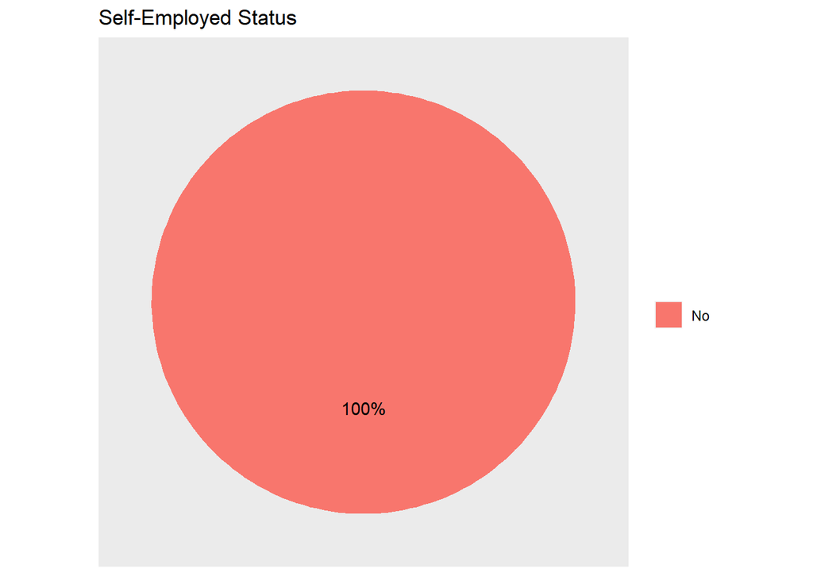

```r
osmi_self <- osmi_demo %>%
  ggplot(aes(x = "", y = after_stat(100*count/sum(count)), fill = self_employed)) +
  geom_bar() +
  geom_text(aes(label = paste0(after_stat(100*count/sum(count)), "%")),
            position = position_stack(vjust = 0.5),
            stat = "count") +
  coord_polar(theta = "y") +
  theme(axis.ticks = element_blank(),
        panel.grid = element_blank(),
        axis.text = element_blank(),
        axis.title = element_blank()) +
  labs(fill = "", title = "Self-Employed Status") +
  scale_fill_discrete(labels = "No")
osmi_self
```

As can be seen, all American respondents were not self-employed; presumably, then, they would be employees of a tech company.

### 2.2.3 Plotting Company Size

We can continue to use the ggplot package to visualize the rest of the data. Looking at the “company_size” variable, we noticed that some of the responses were incorrectly converted into dates (e.g., the response “1-5” was converted to “05 Jan”). Thus, we used the *replace* function to convert those responses into the correct format.

```r
osmi_demo$company_size <- replace(osmi_demo$company_size,
                                  osmi_demo$company_size == "05-Jan",
                                  "1-5")
osmi_demo$company_size <- replace(osmi_demo$company_size,
                                  osmi_demo$company_size == "25-Jun",
                                  "6-25")
```

Similar to self-employed status, now that the data is cleaned we can use *ggplot* to graph our data.

[figure not shown]

```r
osmi_comp_size <- osmi_demo %>%
  ggplot(aes(x = "", y = after_stat(100*count/sum(count)), fill = company_size)) +
  geom_bar() +
  geom_text(aes(label = paste0(round(after_stat(100*count/sum(count)), 2), "%")),
            position = position_stack(vjust = 0.5),
            stat = "count") +
  coord_polar(theta = "y") +
  theme(axis.ticks = element_blank(),
        panel.grid = element_blank(),
        axis.text = element_blank(),
        axis.title = element_blank()) +
  labs(fill = "", title = "Respondent's Company Size") +
  scale_fill_discrete(labels = c("1-5", "100-500", "26-100",
                                 "500-1000", "6-25", "More than 1000", "No Answer"))
osmi_comp_size
```

### 2.2.4 Plotting Job Classification

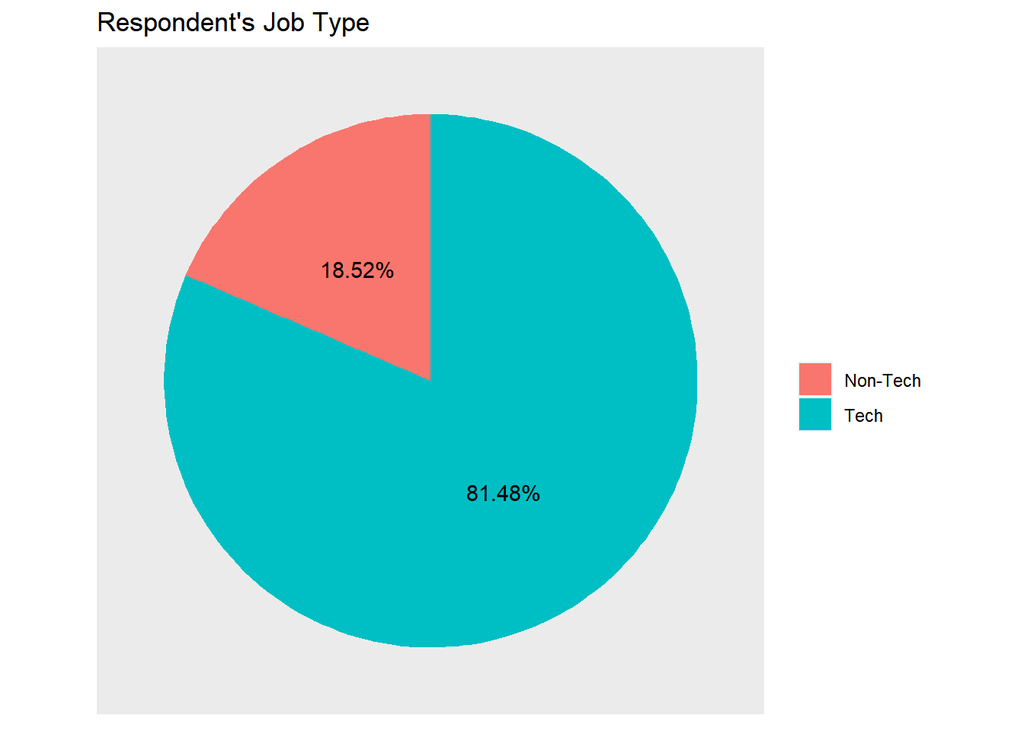

```r
osmi_tech_role <- osmi_demo %>%
  ggplot(aes(x = "", y = after_stat(100*count/sum(count)), fill = tech_role_primary)) +
  geom_bar() +
  geom_text(aes(label = paste0(round(after_stat(100*count/sum(count)), 2), "%")),
            position = position_stack(vjust = 0.5),
            stat = "count") +
  coord_polar(theta = "y") +
  theme(axis.ticks = element_blank(),
        panel.grid = element_blank(),
        axis.text = element_blank(),
        axis.title = element_blank()) +
  labs(fill = "", title = "Respondent's Job Type") +
  scale_fill_discrete(labels = c("Non-Tech", "Tech", "No Answer"))
osmi_tech_role
```

The “tech_role_primary” variable indicates whether the respondent’s job is primarily tech-related or not. Since the entire sample will be used for subsequent analyses, we decided to keep blank responses and classify them as “No Answer”. The results indicate that just over four-fifths of the sample are indeed working tech-dominant roles within their companies, whilst the rest worked non-tech jobs.

### 2.2.5 Plotting Age Distribution

While skimming through the “age” column, we noticed that there was one respondent who listed their age as “223”. As this is clearly a typo (pressing “2” twice instead of once), we manually corrected the typo using the *replace* function. Due to the nature of the “age” variable, it is more appropriate to use a histogram to display such data as opposed to a bar or pie chart. We can use the *geom_histogram* function to create a histogram plot, using the *binwidth* argument to determine how the values should be grouped.

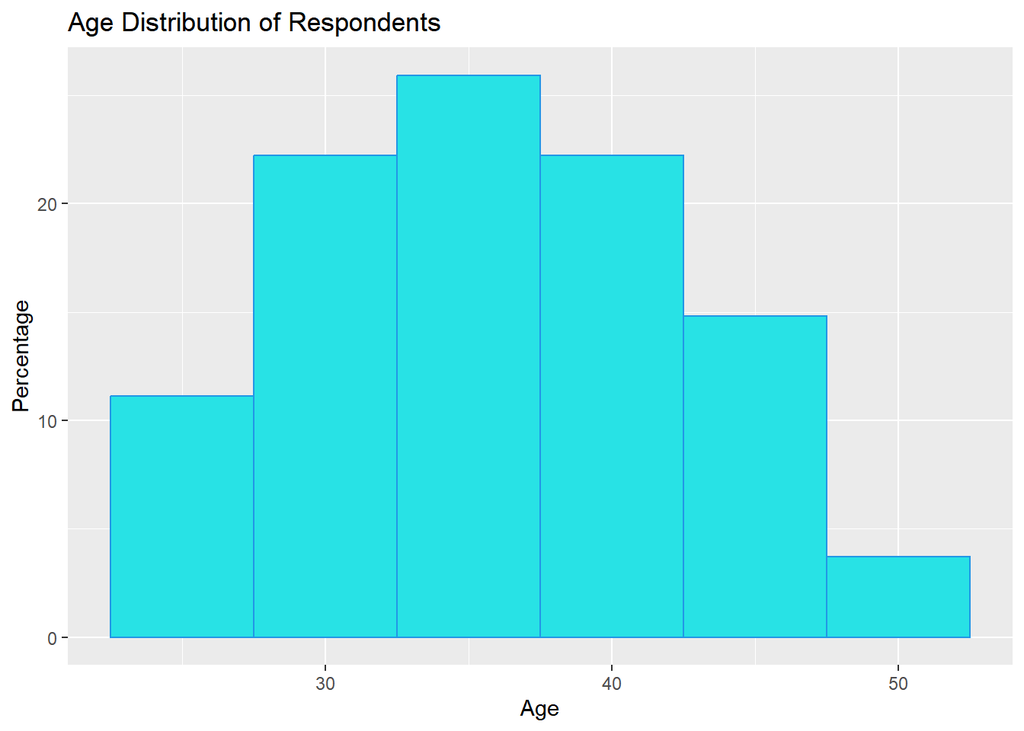

```r
osmi_demo$age <- replace(osmi_demo$age,
                         osmi_demo$age == 223,
                         23)

osmi_age <- osmi_demo %>%
  ggplot(aes(x = age, y = after_stat(100*count/sum(count)))) +
  geom_histogram(color = 4, fill = 5, binwidth = 5) +
  labs(x = "Age", y = "Percentage", title = "Age Distribution of Respondents")
osmi_age
```

The results show that the large majority of respondents are aged between 27-43 years old. A few respondents were around 50 years old, and around 12% of participants were in their mid-twenties.

### 2.2.6 Plotting Gender Distribution

```r
osmi_distinct <- osmi_demo %>%
  distinct(gender)
osmi_distinct
```

```
## # A tibble: 10 × 1
##    gender
##    <chr>
##  1 Female
##  2 female
##  3 afab non-binary
##  4 Male
##  5 male/he/him
##  6 cis-het male
##  7 M
##  8 woman
##  9 Non-binary/Agender
## 10 F
```

The question asking about the participant’s gender appeared to be an open-ended response instead of a multiple choice format, resulting in multiple entries indicating one specific gender (e.g., “female” and “F”). Therefore, we used the *distinct* and *replace* function to combine all the different answers into uniform responses indicating one of three options: male, female, and non-binary.

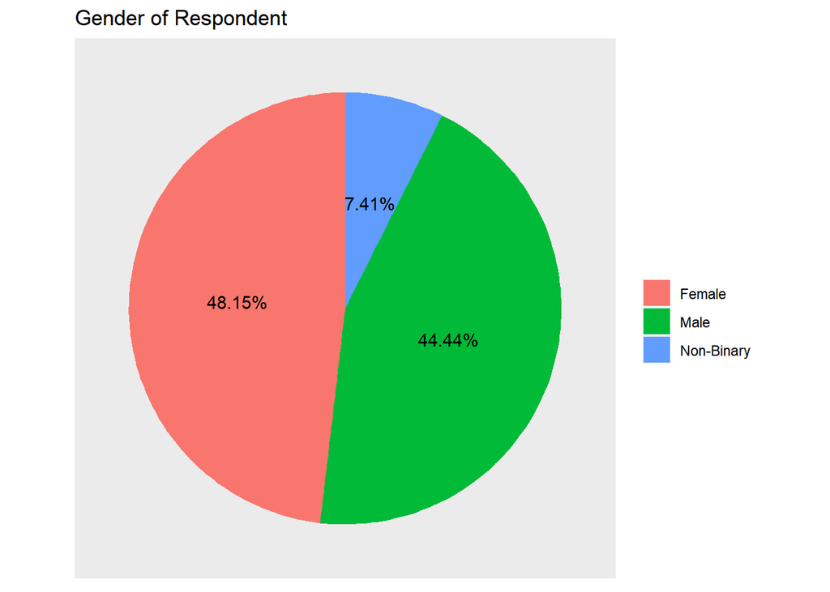

```r
osmi_demo$gender <- replace(osmi_demo$gender,
                            osmi_demo$gender %in% c("female", "Female (cis)", "woman", "F"),
                            "Female")
osmi_demo$gender <- replace(osmi_demo$gender,
                            osmi_demo$gender %in% c("male","male/he/him", "cis-het male", "M"),
                            "Male")
osmi_demo$gender <- replace(osmi_demo$gender,
                            osmi_demo$gender %in% c("afab non-binary","Non-binary/Agender"),
                            "Non-Binary")

osmi_gender <- osmi_demo %>%
  ggplot(aes(x = "", y = after_stat(100*count/sum(count)), fill = gender)) +
  geom_bar() +
  geom_text(aes(label = paste0(round(after_stat(100*count/sum(count)), 2), "%")),
            position = position_stack(vjust = 0.5),
            stat = "count") +
  coord_polar(theta = "y") +
  theme(axis.ticks = element_blank(),
        panel.grid = element_blank(),
        axis.text = element_blank(),
        axis.title = element_blank()) +
  labs(fill = "", title = "Gender of Respondent") +
  scale_fill_discrete(labels = c("Female", "Male", "Non-Binary"))
osmi_gender
```

The results show that between binary genders, the distribution was quite even at roughly 45% of respondents identifying as either male or female. Nearly one-tenth of the sample identified as non-binary.

### 2.2.7 Plotting Ethnic Distribution

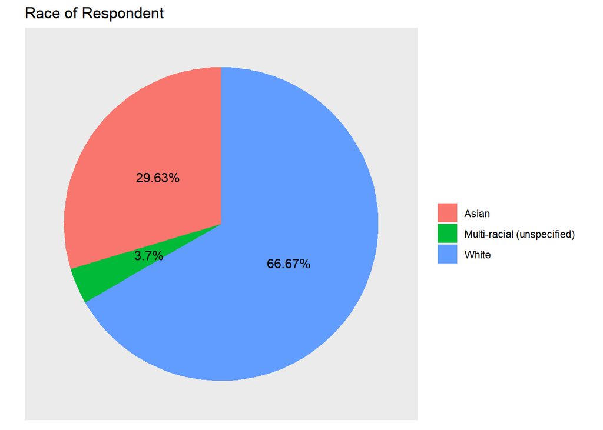

```r
osmi_race <- osmi_demo %>%
  ggplot(aes(x = "", y = after_stat(100*count/sum(count)), fill = race)) +
  geom_bar() +
  geom_text(aes(label = paste0(round(after_stat(100*count/sum(count)), 2), "%")),
            position = position_stack(vjust = 0.5),
            stat = "count") +
  coord_polar(theta = "y") +
  theme(axis.ticks = element_blank(),
        panel.grid = element_blank(),
        axis.text = element_blank(),
        axis.title = element_blank()) +
  labs(fill = "", title = "Race of Respondent") +
  scale_fill_discrete(labels = c("Asian", "Multi-racial (unspecified)", "White"))
osmi_race
```

The data shows that two-thirds of the respondents identified as Caucasian, whilst nearly one-third of repsondents identified as Asian. A small proportion of the sample identified as multi-racial.

### 2.2.8 Plotting State of Residence

For this variable, because the state names are so long, we decided to use the *coord_flip* function to flip the graph 90 degrees, resulting in a sidways bar graph that provides enough space for the state names on the x-axis.

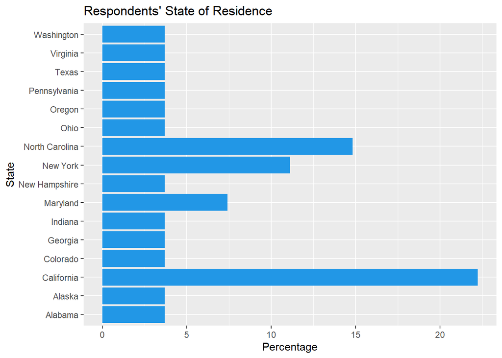

```r
osmi_state <- osmi_demo %>%
  ggplot(aes(x = us_state_res, y = after_stat(100*count/sum(count)))) +
  geom_bar(fill = 4) +
  coord_flip() +
  labs(x = "State", y = "Percentage", title = "Respondents' State of Residence")
osmi_state
```

The data shows that 16 different states were represented in the sample, with more respondents coming from California, North Carolina, New York, and (to a slight extent) Maryland.

## 2.3 Summary of Plots

With 7 plots in total, there is a lot of information here to process and present. For ease of presentation, we can use the *grid.arrange* function in the *gridExtra* library to present multiple charts simultaneously. We can then export this summary page to the file format of our choice for presentation in, for example, a PowerPoint presentation.

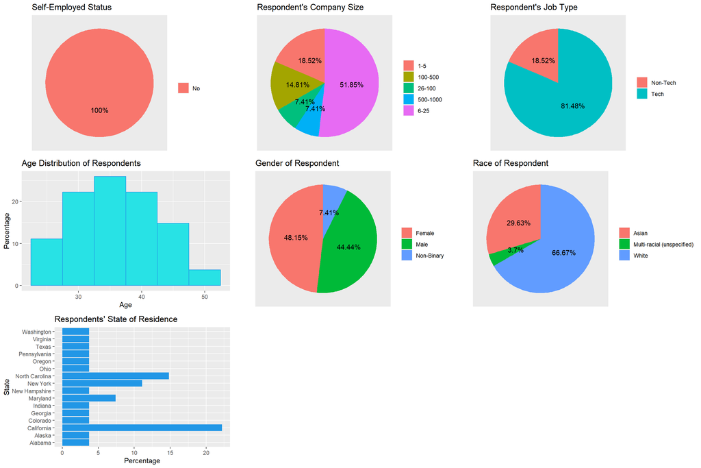

```r
grid.arrange(osmi_self, osmi_comp_size, osmi_tech_role,
             osmi_age, osmi_gender, osmi_race,
             osmi_state,
             ncol = 3)
```

## 2.4 Comments and Remarks

Demographic characteristics usually do not warrant further discussion provided the sample is representative of the population. However, the sample size is noticeably small, with a size of n = 27. This is less than the minimum recommended sample size (30) that usually indicates a representative sample. As such, our conclusions based off the data may not be the most reliable, and will likely require further research. With regards to the sample size, we can confirm this by using the *nrow* function to count how many rows (and therefore observations) our US subset contains.

```r
nrow(osmi_us)
```

```
## [1] 27
```

# 3. Prevalence of Mental Health Disorders in the Tech Industry

## 3.1 Determining Suitable Variables for Analyzing Mental Health Disorder Prevalence

With so many variables in the OSMI survey, we had to determine which variables would best provide us with information regarding how prevalent mental health issues were in the tech industry workplace. Skimming through the dataset, we concluded that the following variables were appropriate: “mh_current_diag” (whether respondents were currently diagnosed with a mental health disorder); “mh_diag_history” (whether respondents had been diagnosed with a mental health disorder in the past), “past_disorder” (the specific mental health disorder the respondent was diagnosed with in the past); and “mh_disorder_treat” (whether respondents had ever sought treatment for a mental health disorder). Some other variables could not be included in the analysis due to its unsuitability (e.g., “possible_disorder”, which provides information on the perceived mental health disorer respondents believe they have, had only 2 responses).

## 3.2 Plotting Mental Health Prevalence Data

### 3.2.1 Plotting Current and Past Mental Health Disorder Prevalence

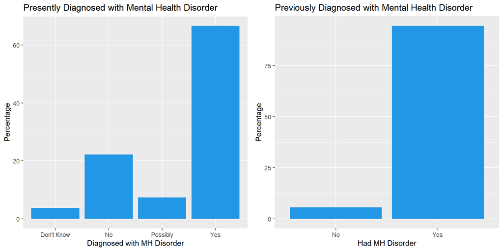

```r
osmi_diag <- osmi_us %>%
  drop_na(mh_current_diag) %>%
  ggplot(aes(x = mh_current_diag, y = after_stat(100*count/sum(count)))) +
  geom_bar(fill = 4) +
  labs(x = "Diagnosed with MH Disorder", y = "Percentage", title = "Presently Diagnosed with Mental Health Disorder")

osmi_diag_past <- osmi_us %>%
  drop_na(mh_diag_history) %>%
  ggplot(aes(x = mh_diag_history, y = after_stat(100*count/sum(count)))) +
  geom_bar(fill = 4) +
  labs(x = "Had MH Disorder", y = "Percentage", title = "Previously Diagnosed with Mental Health Disorder")

grid.arrange(osmi_diag, osmi_diag_past, ncol = 2)
```

The visualization process, much like Section 2.3, combines the *ggplot* with *grid.arrange* functions to visualize and present multiple plots together to convey related and critical information. The data shows that a significant proportion of the sample (over 60%) reported having a mental health disorder at the time of the survey, with just over one-fifth of respondents declaring being completely (mentally) healthy. Nearly 10% of the sample perceive themselves as having a mental health disorder, but are unsure or have not been officially diagnosed yet. Furthermore, almost the entire surveyed sample reported having been previously diagnosed with a mental health disorder.

### 3.2.2 Plotting Mental Health Disorder Classification

```r
osmi_diag_type <- osmi_us %>%
  drop_na(past_disorder) %>%
  distinct(past_disorder)
osmi_diag_type
```

```
## # A tibble: 15 × 1
##    past_disorder
##    <chr>
##  1 ""
##  2 "Anxiety Disorder (Generalized, Social, Phobia, etc)Mood Disorder (Depressio…
##  3 "Stress Response Syndromes"
##  4 "Anxiety Disorder (Generalized, Social, Phobia, etc)Mood Disorder (Depressio…
##  5 "Psychotic Disorder (Schizophrenia, Schizoaffective, etc)"
##  6 "Anxiety Disorder (Generalized, Social, Phobia, etc)Post-traumatic Stress Di…
##  7 "Mood Disorder (Depression, Bipolar Disorder, etc)Eating Disorder (Anorexia,…
##  8 "Mood Disorder (Depression, Bipolar Disorder, etc)"
##  9 "Anxiety Disorder (Generalized, Social, Phobia, etc)Mood Disorder (Depressio…
## 10 "Mood Disorder (Depression, Bipolar Disorder, etc)Attention Deficit Hyperact…
## 11 "Anxiety Disorder (Generalized, Social, Phobia, etc)Mood Disorder (Depressio…
## 12 "Anxiety Disorder (Generalized, Social, Phobia, etc)Mood Disorder (Depressio…
## 13 "Anxiety Disorder (Generalized, Social, Phobia, etc)Mood Disorder (Depressio…
## 14 "Anxiety Disorder (Generalized, Social, Phobia, etc)Mood Disorder (Depressio…
## 15 "Anxiety Disorder (Generalized, Social, Phobia, etc)Obsessive-Compulsive Dis…
```

Calling the “past_disorder” column in the US data subset reveals that there were multiple different responses that may hinder data analysis. The answers were clearly part of a multiple choice list, however certain responses (e.g., row 4) suggest that multiple answers could be selected; this could potentially make interpreting the data in its original form quite hard (e.g., a respondent may answer having a mood and anxiety disorder, another respondent having anxiety and post-traumatic stress disorder, resulting in a number of categories/unique responses that could number in the double digits). To process this data for readability, we first utilized *mutate* to to create a column counting the number of characters for each response, followed by *arrange* to sort the answers by increasing character count.

```r
osmi_diag_type <- osmi_us %>%
  drop_na(past_disorder) %>%
  distinct(past_disorder) %>%
  mutate(past_disorder_char = nchar(past_disorder)) %>%
  arrange(past_disorder_char)
osmi_diag_type
```

```
## # A tibble: 15 × 2
##    past_disorder                                              past_disorder_char
##    <chr>                                                                   <int>
##  1 ""                                                                          0
##  2 "Stress Response Syndromes"                                                25
##  3 "Mood Disorder (Depression, Bipolar Disorder, etc)"                        49
##  4 "Psychotic Disorder (Schizophrenia, Schizoaffective, etc)"                 56
##  5 "Anxiety Disorder (Generalized, Social, Phobia, etc)Post-…                 81
##  6 "Mood Disorder (Depression, Bipolar Disorder, etc)Attenti…                 89
##  7 "Anxiety Disorder (Generalized, Social, Phobia, etc)Mood …                100
##  8 "Mood Disorder (Depression, Bipolar Disorder, etc)Eating …                114
##  9 "Anxiety Disorder (Generalized, Social, Phobia, etc)Obses…                128
## 10 "Anxiety Disorder (Generalized, Social, Phobia, etc)Mood …                129
## 11 "Anxiety Disorder (Generalized, Social, Phobia, etc)Mood …                140
## 12 "Anxiety Disorder (Generalized, Social, Phobia, etc)Mood …                170
## 13 "Anxiety Disorder (Generalized, Social, Phobia, etc)Mood …                199
## 14 "Anxiety Disorder (Generalized, Social, Phobia, etc)Mood …                210
## 15 "Anxiety Disorder (Generalized, Social, Phobia, etc)Mood …                213
```

The resulting table allowed us to note that the answer indicating a **single** mental health disorder with the most text contained 56 characters (row 4), whereas all answers indicating **multiple** disorders contained more than 56 characters (row 5 onwards). Using this information, we can then utilize the *case_when* function inside the *mutate* function to convert all answers containing more than 56 characters into a single, uniform response of “Comorbid/Multiple Disorders”, then plot the transformed data using *ggplot*. Note that we used the *filter* function to remove blank responses as we ascertained that these respondents answers “No” when asked whether they were previously diagnosed with a mental health disorder.

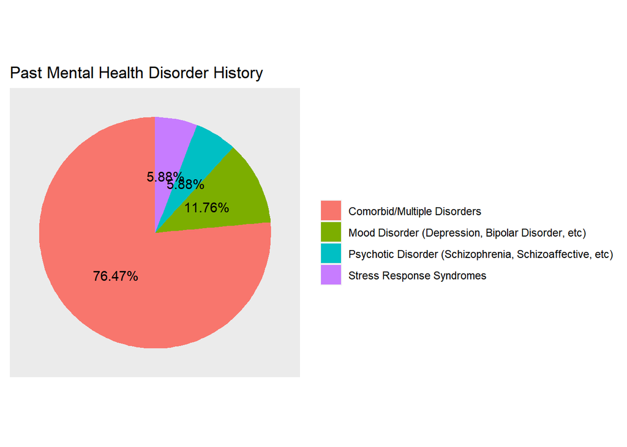

```r
osmi_diag_type_graph <- osmi_us %>%
  drop_na(past_disorder) %>%
  filter(past_disorder != "") %>%
  mutate(past_disorder = case_when(
    nchar(past_disorder) > 56 ~ "Comorbid/Multiple Disorders",
    nchar(past_disorder) == 25 ~ "Stress Response Syndromes",
    nchar(past_disorder) == 49 ~ "Mood Disorder (Depression, Bipolar Disorder, etc)",
    nchar(past_disorder) == 56 ~ "Psychotic Disorder (Schizophrenia, Schizoaffective, etc)")) %>%
  ggplot(aes(x = "", y = after_stat(100*count/sum(count)), fill = past_disorder)) +
  geom_bar() +
  geom_text(aes(label = paste0(round(after_stat(100*count/sum(count)), 2), "%")),
            position = position_stack(vjust = 0.5),
            stat = "count") +
  coord_polar(theta = "y") +
  theme(axis.ticks = element_blank(),
        panel.grid = element_blank(),
        axis.text = element_blank(),
        axis.title = element_blank()) +
  labs(fill = "", title = "Past Mental Health Disorder History")
osmi_diag_type_graph
```

The data shows that of the respondents who identified as having been previously diagnosed with a mental health disorder, roughly three quarters identified as having comorbid (i.e., multiple) disorders. The second most common disorder were mood disorders (e.g., depression), with psychotic (e.g., schizophrenia) and stress disorders being tied for the third most common disorder. This signifies that most mentally ill individuals in the sample often have the burden of struggling with more than one mental health disorder.

### 3.2.3 Plotting Treatment Staus of Mental Health Disorders

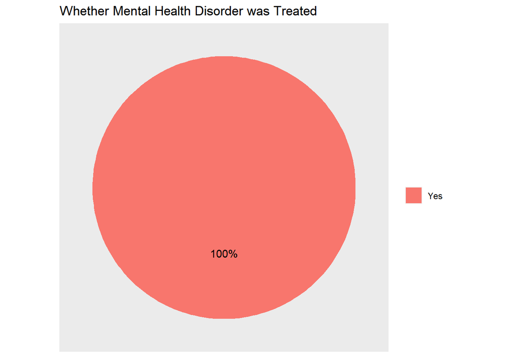

```r
osmi_treated <- osmi_us %>%
  drop_na(past_disorder) %>%
  filter(past_disorder != "") %>%
  ggplot(aes(x = "", y = after_stat(100*count/sum(count)), fill = mh_disorder_treat)) +
  geom_bar() +
  geom_text(aes(label = paste0(round(after_stat(100*count/sum(count)), 2), "%")),
            position = position_stack(vjust = 0.5),
            stat = "count") +
  scale_fill_discrete(label = "Yes") +
  coord_polar(theta = "y") +
  theme(axis.ticks = element_blank(),
        panel.grid = element_blank(),
        axis.text = element_blank(),
        axis.title = element_blank()) +
  labs(fill = "", title = "Whether Mental Health Disorder was Treated")
osmi_treated
```

The data shows that all individuals who had a mental health disorder sought treatment, a data point worth further discussion (see below).

## 3.3 Summary of Plots

Much like Section 2.3, we can use the *grid.arrange* function to present all the created charts in Section 3 simultaneously for presentation purposes.

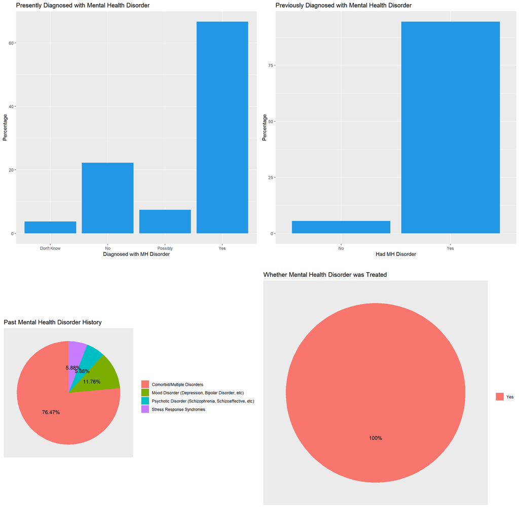

```r
grid.arrange(osmi_diag, osmi_diag_past,
             osmi_diag_type_graph, osmi_treated,
             ncol = 2)
```

## 3.4 Discussion

Altogether, the data suggests that the prevalence of mental health disorders in the American tech industry is abnormally high relative to the general population based on statistics from [John Hopkins](https://www.hopkinsmedicine.org/health/wellness-and-prevention/mental-health-disorder-statistics), but supports the idea that most individuals with such disorders tend to have comorbid disorders. The most common disorders globally are also reflected in the sample, with mood and psychotic disorders accounting for the majority of responses indicating a single mental health disorder. On the optimistic side, the last graph unequivocally suggests that clinical patients in the sample have sought treatment for their mental health disorders at some point in their lives, suggesting that the mental healthcare support for employees in the tech industry is adequate in terms of employees’ awareness of such options. Since treatment options do not appear to be an issue, a topic worth researching is the pervasiveness of mental health disorders in the tech industry, and how to best mitigate the prevalence of such disorders in the field.

As mentioned in Section 2.4, it is important to take caution in the reliability of the conclusions made in this analysis, as the small sample size is, by nature, prone to skewing of results, and may lead to the rather extreme outcomes and observations seen in the data visualizations. Any findings made in this section should be confirmed by a replication of the survey before using them as a basis for further research.

# 4. Workplace Related Effects of Mental Health Issues

## 4.1 Creating a Data Subset

We can first create a subset of the US dataset by using *select* to include only relevant variables. In this case, we defined “workplace related effects” as any variables assessing the actual or perceived impacts, positive or negative, of any mental health factors on workplace productivity. These include more individual factors (e.g., having a mental health disorder and how it impacts productivity) as well as more structural factors (e.g., perceived level of mental health support in the tech industry as a whole).

```r
osmi_mh_effects <- osmi_us %>%
  select(21, 56:58, 62, 64:68, 70, 72)
head(osmi_mh_effects)
```

```
## # A tibble: 6 × 12
##   mh_employer_importance mh_work_disrupt_treated mh_work_disrupt_untreated
##                    <dbl> <chr>                   <chr>
## 1                      1 Not applicable to me    Not applicable to me
## 2                      1 Not applicable to me    Not applicable to me
## 3                      5 Sometimes               Often
## 4                      9 Rarely                  Often
## 5                      7 Sometimes               Often
## 6                      6 Sometimes               Sometimes
## # ℹ 9 more variables: mh_other_discuss_bad_reveal <chr>,
## #   mh_discuss_potential_employer <chr>, mh_openid <lgl>,
## #   mh_openid_outcome <lgl>, mh_openid_outcome_description <dbl>,
## #   mh_perceived_rx <dbl>, mh_observe_bad_rx <chr>, mh_observe_good_rx <chr>,
## #   mh_perceived_industry_support <dbl>
```

## 4.2 Plotting Effects of Mental Health on Workplace Productivity

### 4.2.1 Plotting Perceived Workplace Disruption with Mental Health Disorder

Here, we plot the variables “mh_work_disrupt_treated” (perceived disruption of treated mental health disorders on workplace productivity) and “mh_work_disrupt_untreated” (perceived disruption of **untreated** mental health disorders on workplace productivity) together using *gird.arrange* as these variables are related to each other and can provide useful information when presented side-by-side. We also use the *filter* function to leave out answers from respondents indicating they did not have any mental health disorders (i.e., the questions were not relevant to them).

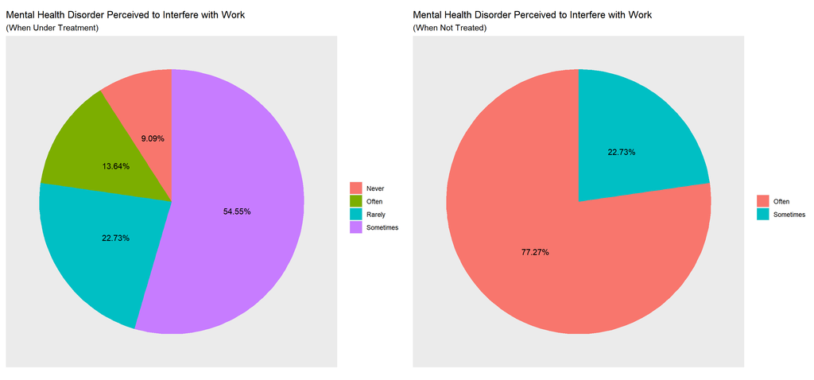

```r
osmi_dis_treat <- osmi_mh_effects %>%
  filter(mh_work_disrupt_treated != "Not applicable to me") %>%
  ggplot(aes(x = "", y = after_stat(100*count/sum(count)), fill = mh_work_disrupt_treated)) +
  geom_bar() +
  geom_text(aes(label = paste0(round(after_stat(100*count/sum(count)), 2), "%")),
            position = position_stack(vjust = 0.5),
            stat = "count") +
  coord_polar(theta = "y") +
  theme(axis.ticks = element_blank(),
        panel.grid = element_blank(),
        axis.text = element_blank(),
        axis.title = element_blank()) +
  labs(fill = "", title = "Mental Health Disorder Perceived to Interfere with Work", subtitle = "(When Under Treatment)")

osmi_dis_untreat <- osmi_mh_effects %>%
  filter(mh_work_disrupt_untreated != "Not applicable to me") %>%
  ggplot(aes(x = "", y = after_stat(100*count/sum(count)), fill = mh_work_disrupt_untreated)) +
  geom_bar() +
  geom_text(aes(label = paste0(round(after_stat(100*count/sum(count)), 2), "%")),
            position = position_stack(vjust = 0.5),
            stat = "count") +
  coord_polar(theta = "y") +
  theme(axis.ticks = element_blank(),
        panel.grid = element_blank(),
        axis.text = element_blank(),
        axis.title = element_blank()) +
  labs(fill = "", title = "Mental Health Disorder Perceived to Interfere with Work",
       subtitle = "(When Not Treated)")

grid.arrange(osmi_dis_treat,
             osmi_dis_untreat,
             ncol = 2)
```

The data shows that there is a major difference as to how respondents view how severe mental health disorder disrupts productivity based on treatment status. Given that the mental health disorder is treated, almost 90% of respondents believed that the mental health disorder would never, rarely, or only sometimes affect productivity. However, when assuming the mental health disorder is left untreated, roughly three quarters of the sample believed the impacts to be quite severe (i.e., disrupting work often).

### 4.2.2 Plotting Effects of Being Openly Identified with Mental Health Disorder

Much like Section 4.2.1, we use *grid.arrange* here to plot three related variables together, “mh_openid_outcome” (perceived careeer impacts of being publicly identified with a mental health disorder in the workplace) grouped by “mh_openid” (whether respondent openly associates with a mental health disorder in the workplace) responses, as well as “mh_perceived_rx” (a coworker’s reaction to the respondent being openly identified with a mental disorder in a hypothetical scenario).

```r
str(osmi_mh_effects)
```

```
## tibble [27 × 12] (S3: tbl_df/tbl/data.frame)
##  $ mh_employer_importance       : num [1:27] 1 1 5 9 7 6 7 1 3 2 ...
##  $ mh_work_disrupt_treated      : chr [1:27] "Not applicable to me" "Not applicable to me" "Sometimes" "Rarely" ...
##  $ mh_work_disrupt_untreated    : chr [1:27] "Not applicable to me" "Not applicable to me" "Often" "Often" ...
##  $ mh_other_discuss_bad_reveal  : chr [1:27] "No" "Yes" "No" "Yes" ...
##  $ mh_discuss_potential_employer: chr [1:27] "No" "No" "No" "No" ...
##  $ mh_openid                    : logi [1:27] FALSE FALSE FALSE FALSE FALSE FALSE ...
##  $ mh_openid_outcome            : logi [1:27] NA NA NA NA NA NA ...
##  $ mh_openid_outcome_description: num [1:27] NA NA NA NA NA NA NA NA NA NA ...
##  $ mh_perceived_rx              : num [1:27] 4 1 8 8 5 4 10 5 5 2 ...
##  $ mh_observe_bad_rx            : chr [1:27] "No" "Maybe/Not sure" "Maybe/Not sure" "Yes, I experienced" ...
##  $ mh_observe_good_rx           : chr [1:27] "No" "No" "Maybe/Not sure" "Yes, I experienced" ...
##  $ mh_perceived_industry_support: num [1:27] 2 1 5 1 3 4 2 3 2 2 ...
```

In the *ggplot* function, we also used the *breaks* argument in the *scale_x_continuous* function to manually denote which values should be marked on the x-axis, indicating the minimum, middle, and maximum possible response values (0, 5, and 10 respectively). Since no respondent provided an answer of “0”, we also used the *expand_limits* function to ensure the x-axis showed the minimum possible value even though no responses were recorded.

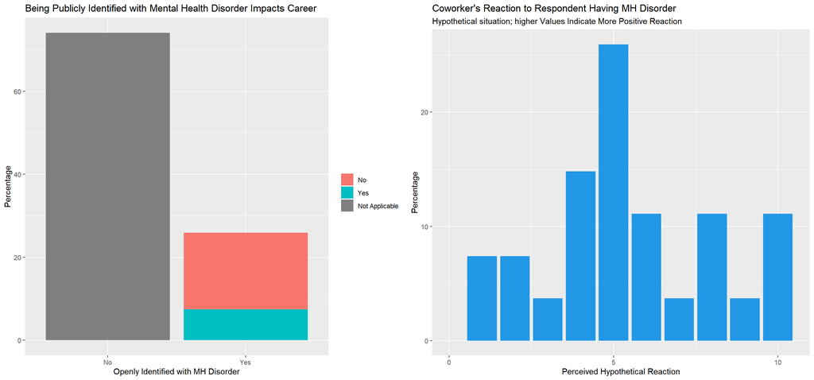

```r
osmi_openid <- osmi_mh_effects %>%
  ggplot(aes(x = mh_openid, y = after_stat(100*count/sum(count)), fill = mh_openid_outcome)) +
  geom_bar() +
  labs(fill = "", x = "Openly Identified with MH Disorder", y = "Percentage",
       title = "Being Publicly Identified with Mental Health Disorder Impacts Career") +
  scale_x_discrete(labels = c("No", "Yes")) +
  scale_fill_discrete(labels = c("No", "Yes", "Not Applicable"))

osmi_per_rx <- osmi_mh_effects %>%
  drop_na(mh_perceived_rx) %>%
  mutate(mh_perceived_rx = as.integer(mh_perceived_rx)) %>%
  ggplot(aes(x = mh_perceived_rx, y = after_stat(100*count/sum(count)))) +
  geom_bar(fill = 4) +
  labs(x = "Perceived Hypothetical Reaction", y = "Percentage",
       subtitle = "Hypothetical situation; higher Values Indicate More Positive Reaction",
       title = "Coworker's Reaction to Respondent Having MH Disorder") +
  scale_x_continuous(breaks = c(0, 5, 10)) +
  expand_limits(x = 0)

grid.arrange(osmi_openid,
             osmi_per_rx,
             ncol = 2)
```

The data shows that only about one quarter of the sample is openly identified in the workplace as having a mental health disorder. Of those respondents, the majority believed that their status did not affect their careers, although some respondents perceived an impact on career opportunities. When presented with a hypothetical scenario about being openly identified with a mental health disorder, the responses were somewhat normally distributed with the majority of responses centered around the median response value (5), although respondents tended to answer on the more positive side (around 60% answered with a value of 5 or greater). Together, the results suggest that a small proportion of individuals within the tech industry are openly identified as being mentally ill; however, even when openly identified, it is more likely that coworkers will react either neutrally or positively to such news. This implies that coworkers in the workplace are generally perceived as being quite tolerant and understanding of mental health issues, an observation that may apply to the work culture in America as a whole (further data required).

### 4.2.3 Plotting Perceived Industry Support

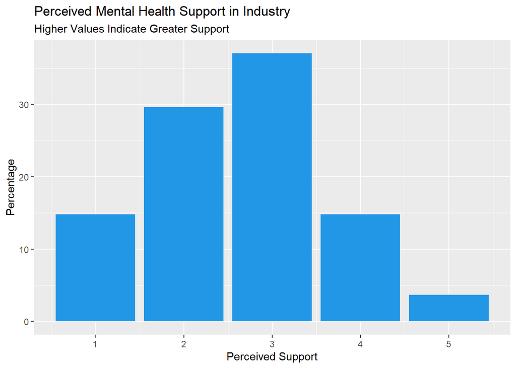

```r
osmi_per_ind_sup <- osmi_mh_effects %>%
  drop_na(mh_perceived_industry_support) %>%
  ggplot(aes(x = mh_perceived_industry_support, y = after_stat(100*count/sum(count)))) +
  geom_bar(fill = 4) +
  labs(x = "Perceived Support", y = "Percentage",
       title = "Perceived Mental Health Support in Industry",
       subtitle = "Higher Values Indicate Greater Support")
osmi_per_ind_sup
```

The data from the “mh_perceived_industry_support” (the respondent’s opinion of how well the tech industry supports employees with mental health issues) variable suggests that most respondents believe the tech industry needs to improve how they handle mental health issues with respect to their employees. This is based off of the data which indicates around 45% of respondents perceived industry support to be at a value of less than 3, which would translate to between average to below-average quality of industrial support (assuming that the Likert scale captures a linear spectrum of responses). On the flip side, under one-fifth of the sample perceived industry support to be of above-average quality (response values of more than 3). Approximately one-third of respondents thought industry support was mediocre (response value of 3).

### 4.2.4 Plotting Instances of Workplace Mental Health Situations

The following variables, “mh_observe_bad_rx” and “mh_observe_good_rx”, indicate whether the respondent ever witnessed a mental health situation that was handled either unwell or well, respectively. The options to these questions included a distinction between **witnessing** (observer) and **experiencing** (participant) a situation, as well as an option for uncertainty (“Maybe/Not sure”).

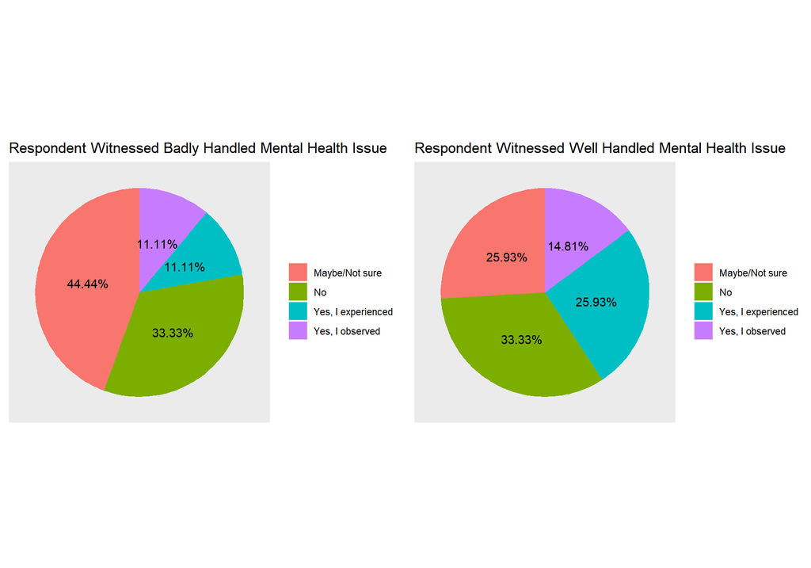

```r
osmi_bad_rx <- osmi_mh_effects %>%
  drop_na(mh_observe_bad_rx) %>%
  ggplot(aes(x = "", y = after_stat(100*count/sum(count)), fill = mh_observe_bad_rx)) +
  geom_bar() +
  geom_text(aes(label = paste0(round(after_stat(100*count/sum(count)), 2), "%")),
            position = position_stack(vjust = 0.5),
            stat = "count") +
  coord_polar(theta = "y") +
  theme(axis.ticks = element_blank(),
        panel.grid = element_blank(),
        axis.text = element_blank(),
        axis.title = element_blank()) +
  labs(fill = "", title = "Respondent Witnessed Badly Handled Mental Health Issue")

osmi_good_rx <- osmi_mh_effects %>%
  drop_na(mh_observe_good_rx) %>%
  ggplot(aes(x = "", y = after_stat(100*count/sum(count)), fill = mh_observe_good_rx)) +
  geom_bar() +
  geom_text(aes(label = paste0(round(after_stat(100*count/sum(count)), 2), "%")),
            position = position_stack(vjust = 0.5),
            stat = "count") +
  coord_polar(theta = "y") +
  theme(axis.ticks = element_blank(),
        panel.grid = element_blank(),
        axis.text = element_blank(),
        axis.title = element_blank()) +
  labs(fill = "", title = "Respondent Witnessed Well Handled Mental Health Issue")

grid.arrange(osmi_bad_rx,
             osmi_good_rx,
             ncol = 2)
```

The data suggests that there may be no significant differences in how respondents answered to either question. In both cases, one-third of respondents did not witness a badly or well handled mental health issue. With regards to badly handled situations, around 45% of the sample reported being uncertain about whether they witnessed such an incident, whilst approximately one-fifth of the sample reported either having observed or experienced such an event. In terms of well handled mental health issues, roughly 40% of respondents either observed or experienced a well handled mental health problem, while about one quarter of the sample was uncertain about witnessing such an incident.

The data does not suggest a significant pattern in answers across the two variables, suggesting they may not be related to each other (i.e., answering one of the questions does not predict a certain response in the other). Only comparative (and not correlational) observations can, therefore, be made about the results. First, more respondents see positive mental health related interactions in the workplace as compared to negative ones. This suggests that, with respect to more public mental health situations, coworkers and employers tend to resolve such problems in a satisfactory way. Second, a significant portion of respondents (especially for badly handled issues) answered as possibly having witnessed a mental health issue event that was resolved positively and/or negatively. This slightly confounds the findings and conclusions made about the data, as we do not have enough information to make conclusions about those responses (e.g, as to whether the event they are referring to is mental health related to begin with, or whether they were uncertain as to whether the outcome was positive or negative). Further research should seek to qualify or quantify the nature of participants’ uncertainty (e.g., open-ended text response with thematic analysis and coding of answers).

### 4.2.5 Plotting Employer’s Level of Importance Placed on Mental Health

The following variable, “mh_employer_importance”, assesses the how much the respondent perceives their employer to value mental health.

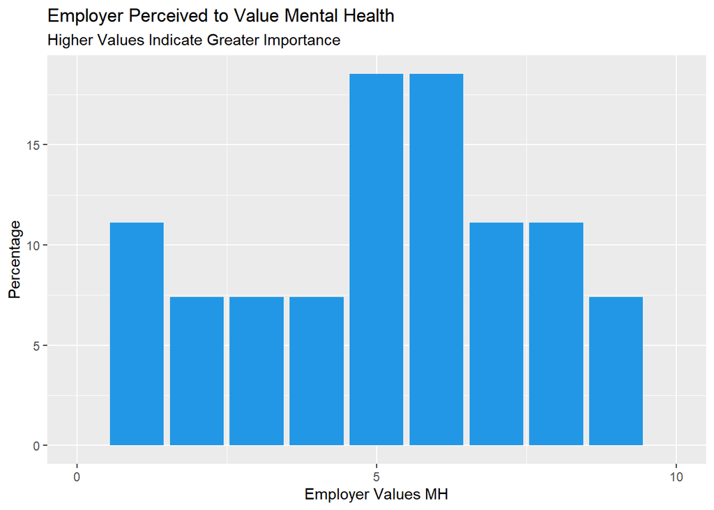

```r
osmi_emp_mh_imp <- osmi_mh_effects %>%
  drop_na(mh_employer_importance) %>%
  ggplot(aes(x = mh_employer_importance, y = after_stat(100*count/sum(count)))) +
  geom_bar(fill = 4) +
  labs(x = "Employer Values MH", y = "Percentage",
       subtitle = "Higher Values Indicate Greater Importance", title = "Employer Perceived to Value Mental Health") +
  scale_x_continuous(breaks = c(0, 5, 10)) +
  expand_limits(x = c(0, 10))
osmi_emp_mh_imp
```

### 4.2.6 Summary of Plots

Just like before, we can use *grid.arrange* to present all plots together for exporting and presentation purposes.

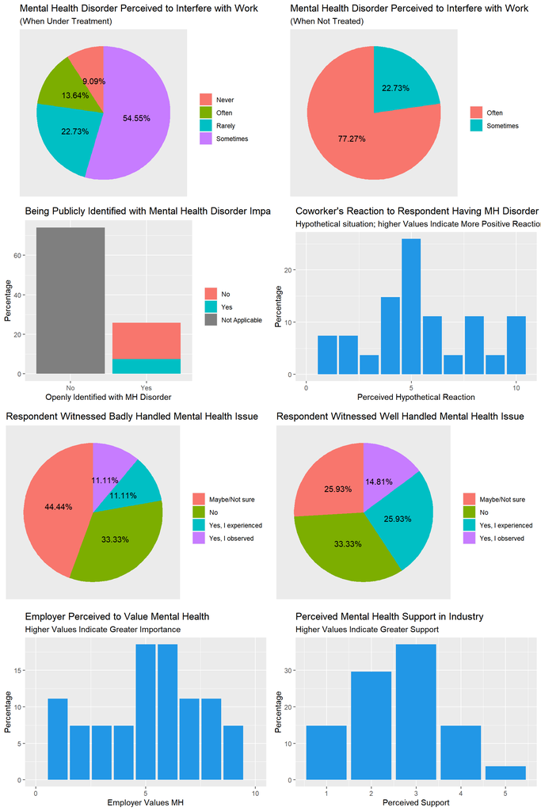

```r
grid.arrange(osmi_dis_treat, osmi_dis_untreat, osmi_openid,
             osmi_per_rx, osmi_bad_rx, osmi_good_rx,
             osmi_emp_mh_imp, osmi_per_ind_sup,
             ncol = 2)
```

### 4.2.7 Discussion

The variables analyzed in this Section provide some insight into how the sample perceives mental health issues to affect workplace conditions and/or work performance. First, the data shows that work productivity is perceived to be affected if a mental health disorder is left untreated (Section 4.2.1). These results suggest that respondents greatly value mental health treatment, and also believe that treatment can affect their work productivity. Together, the data implies that mental healthcare is of great value at both the individual level (e.g., perceived and/or real benefits) and the organizational level (i.e., improved mental health status may result in indirect improvements to work efficiency and performance). Further longitudinal research could evaluate objective measures of work performance pre- and post-treatment to support these findings.

Second, a small proportion of employees in the tech industry are openly identified as being mentally ill in their workplace, yet the majority of these employees don’t believe that their status impacts their career prospects. Additionally, given a hypothetical scenario, a slight majority believed that a coworker would react neutrally or positively when learning that they had a mental health disorder (Section 4.2.2). These findings imply that coworkers in the workplace are generally perceived as being quite tolerant and understanding of mental health issues, an observation that may apply to the work culture in America as a whole (further data required).

Third, a huge majority of respondents believe that mental health support in the tech industry is at an average or worse level (Section 4.2.3). These initial findings warrant further investigation into why respondents believe mental health support is inadequate through interviews and qualitative analysis of data, or through quantitative analysis of variables that could potentially reflect mental health support in industry (e.g., extent of mental health coverage benefits as monetary values).

Fourth, there were no clear trends between witnessing a badly handled mental health situation and witnessing a well handled mental health situation in the workplace (Section 4.2.4). The data does not suggest a significant pattern in answers across the two variables, suggesting they may not be related to each other (i.e., answering one of the questions does not predict a certain response in the other). Only comparative (and not correlational) observations can, therefore, be made about the results. More respondents see positive mental health related interactions in the workplace as compared to negative ones, suggesting that with respect to more public mental health situations, coworkers and employers tend to resolve such problems in a satisfactory way. A limitation of the data is that a significant portion of respondents (especially for badly handled issues) answered as possibly having witnessed a mental health issue event that was resolved positively and/or negatively. but were unsure or uncertain. This slightly confounds the findings and conclusions made about the data, as we do not have enough information to make conclusions about those responses (e.g, as to whether the event they are referring to is mental health related to begin with, or whether they were uncertain as to whether the outcome was positive or negative). Further research should seek to qualify or quantify the nature of participants’ uncertainty (e.g., open-ended text response with thematic analysis and coding of answers).

Finally, the majority of employers in the workplace are perceived as placing an average or moderate amount of emphasis on mental health (Section 4.2.5). These findings suggest that research and applied projects can be conducted to improve employers’ view of mental health as an issue worth addressing, as we have seen previously that mental health issues, just like physical health, can impact one’s productivity in the long run.

# 5. Interpersonal Comfort Discussing Mental Health in the Workplace

## 5.1 Creating a Data Subset

As with before, we can first create a subset of the US dataset by using *select* to include only relevant variables. Here, we were interested in investigating how workplace conditions, as it pertains to mental health, might be related with a willingness to discuss a topic that for some may be considered a stigma or taboo. We found two suitable dependent variables, both related to the willingness to discuss mental health with employees or employers (“comfort_coworker” and “comfort_supervisor” respectively), in addition to variables that we believe may point towards a company’s approach to mental health issues (e.g., “mh_coverage” determines whether the respondent’s company provides medical coverage for mental health problems).

Note that in this line of code, we have used the column numbers as opposed to the variable names for conciseness. Furthermore, we have dropped any observations that did not include a response to either “comfort_supervisor” or “comfort_coworker”, our “outcome” variables for analysis.

```r
osmi_comfort <- osmi_us %>%
  select(5:13, 15:16, 18) %>%
  drop_na(comfort_supervisor, comfort_coworker)
head(osmi_comfort)
```

```
## # A tibble: 6 × 12
##   mh_coverage  mh_options_aware mh_employer_discuss mh_resource_employer_offer
##   <chr>        <chr>            <chr>               <chr>
## 1 I don't know No               No                  I don't know
## 2 No           No               No                  No
## 3 No           Yes              Yes                 Yes
## 4 Yes          Yes              No                  No
## 5 I don't know Yes              No                  Yes
## 6 No           Yes              Yes                 No
## # ℹ 8 more variables: anon_protect <chr>, mh_leave_difficulty <chr>,
## #   mh_ph_discuss_coworker <chr>, comfort_supervisor <chr>,
## #   mh_employer_discuss_personal <lgl>, comfort_coworker <chr>,
## #   mh_coworker_discuss_personal <lgl>, mh_coworker_discuss_personal_2 <lgl>
```

## 5.2 Plotting Workplace Variables Grouped By Comfort Discussing Mental Health

The following graphs will be presented in pairs as each workplace condition/variable is plotted twice (once against each of our “outcome” variables).

### 5.2.1 Plotting Mental Health Coverage

Before plotting “mh_coverage” (indicating whether the respondent’s mental health treatments are covered by their company), it must first be recognized that the answers can be thought of as being somewhat ordinal in nature; a “not applicable” response (value “Not eligible for coverage / NA”), followed by a “low” value (“No”), a “medium” value (“I don’t know”, reflecting a possibility of having coverage), and a “high” value (“Yes”). Therefore, we can use the *factor* function to arrange “mh_coverage” responses in an ordered fashion, then follow up with *ggplot* to visualize the data in an intuitive way combined with *grid.arrange* to present both plots together.

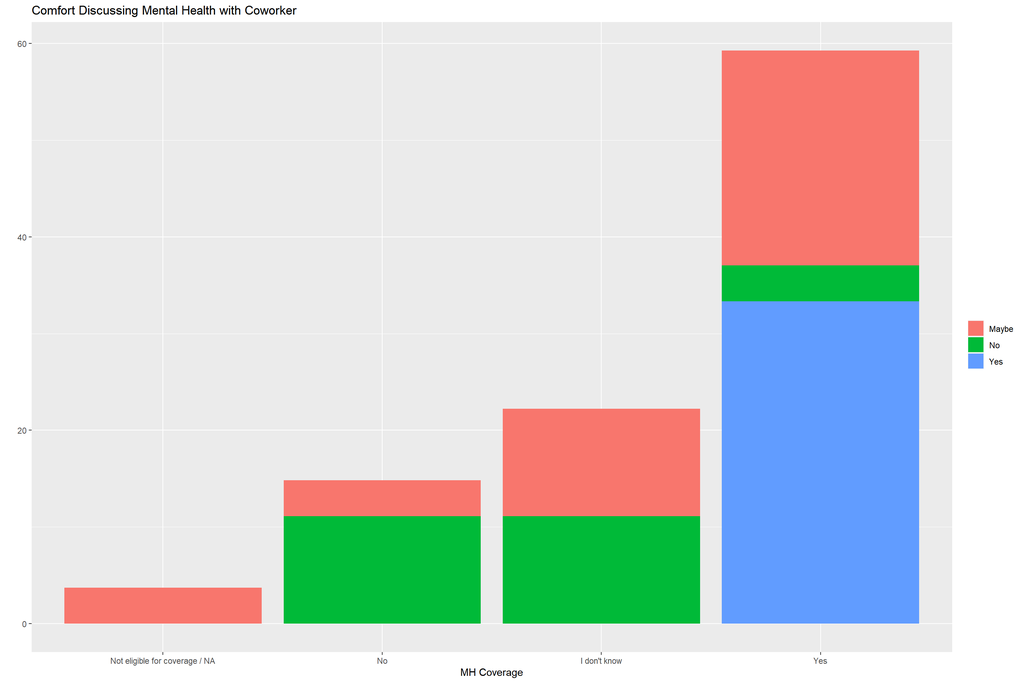

```r
osmi_comfort$mh_coverage <- factor(osmi_comfort$mh_coverage, order = TRUE,
                                           levels = c("Not eligible for coverage / NA", "No", "I don't know", "Yes"))

osmi_cov_com_cow <- osmi_comfort %>%
  drop_na(mh_coverage) %>%
  ggplot(aes(x = mh_coverage, y = after_stat(100*count/sum(count)), fill = comfort_coworker)) +
  geom_bar() +
  labs(x = "MH Coverage", y = "", fill = "", title = "Comfort Discussing Mental Health with Coworker")
osmi_cov_com_cow
```

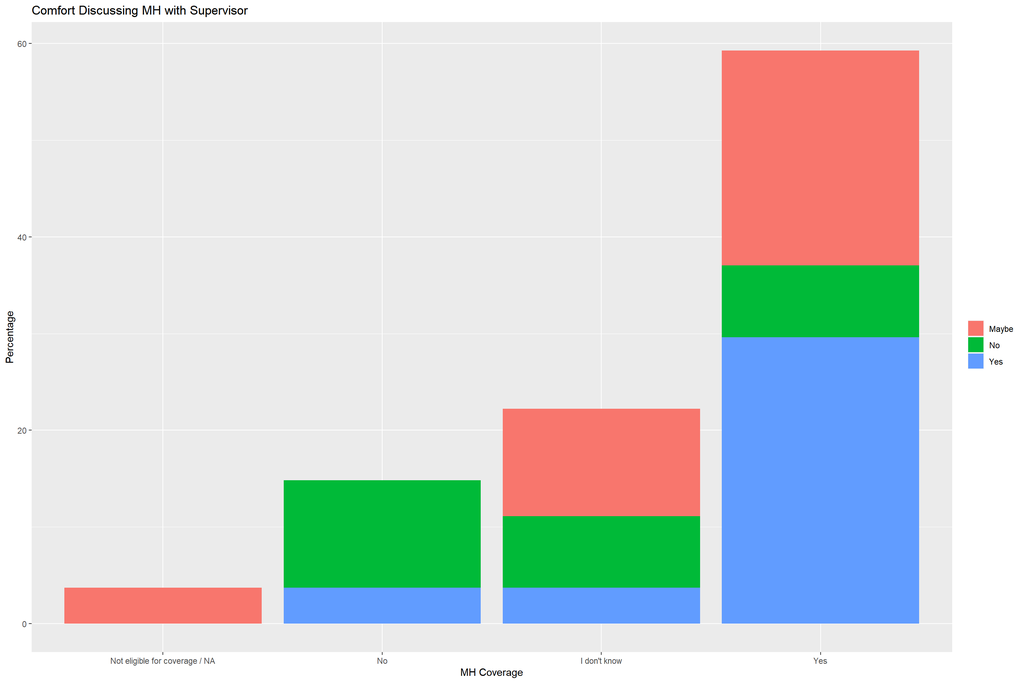

```r
osmi_cov_sup <- osmi_comfort %>%
  drop_na(mh_coverage) %>%
  ggplot(aes(x = mh_coverage, y = after_stat(100*count/sum(count)), fill = comfort_supervisor)) +
  geom_bar() +
  labs(x = "MH Coverage", y = "Percentage", fill = "",
       title = "Comfort Discussing MH with Supervisor")
osmi_cov_sup
```

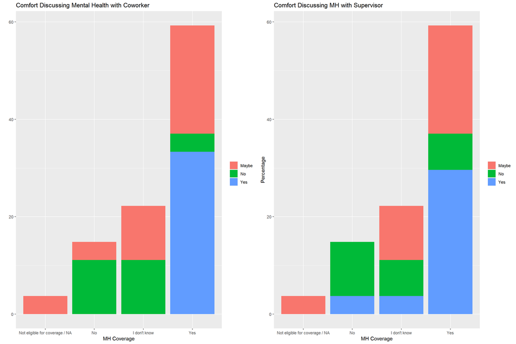

```r
grid.arrange(osmi_cov_com_cow,
             osmi_cov_sup,
             ncol = 2)
```

Note that the “Not eligible for coverage” group does not fit neatly into the ordinal hierarchy of these variables, and was therefore excluded from further analysis. It is worth mentioning that as this option accounts for less than 5% of responses, it can be observed that a very small proportion of the sample may have reduced accessibility to mental healthcare as it pertains to employee/company benefits.

### 5.2.2 Plotting Awareness of Mental Health Options

The following variable “mh_options_aware” indicates whether respondents are aware as to what mental health options they have under their employer-provided mental health coverage.

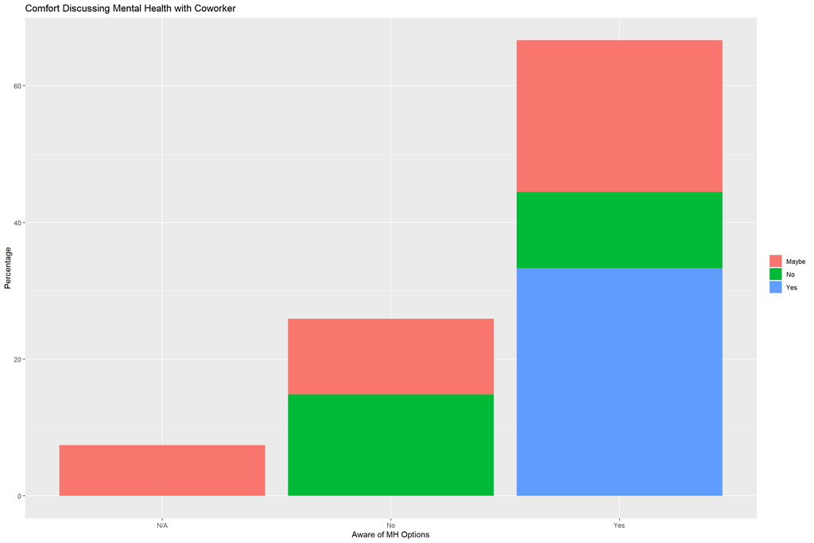

```r
osmi_opt_com_cow <- osmi_comfort %>%
  drop_na(mh_options_aware) %>%
  ggplot(aes(x = mh_options_aware, y = after_stat(100*count/sum(count)), fill = comfort_coworker)) +
  geom_bar() +
  labs(x = "Aware of MH Options", y = "Percentage", fill = "",
       title = "Comfort Discussing Mental Health with Coworker")
osmi_opt_com_cow
```

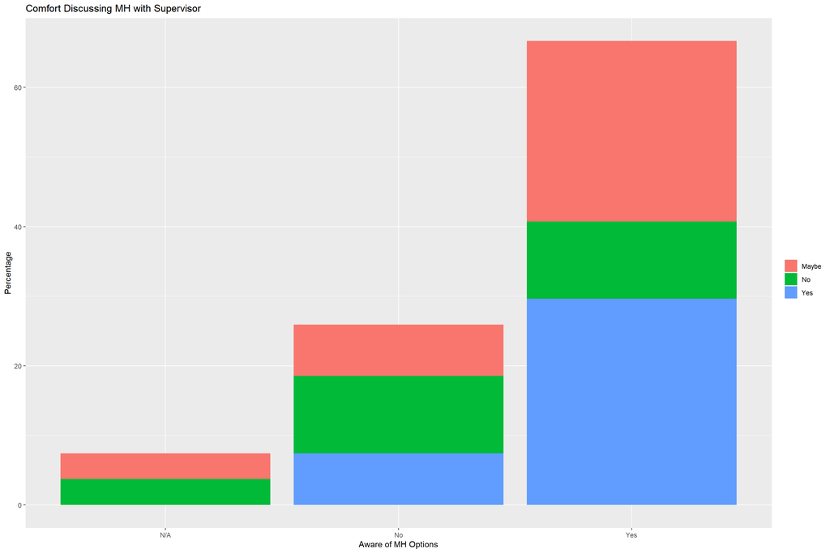

```r
osmi_opt_sup <- osmi_comfort %>%
  drop_na(mh_options_aware) %>%
  ggplot(aes(x = mh_options_aware, y = after_stat(100*count/sum(count)), fill = comfort_supervisor)) +
  geom_bar() +
  labs(x = "Aware of MH Options", y = "Percentage", fill = "",
       title = "Comfort Discussing MH with Supervisor")
osmi_opt_sup
```

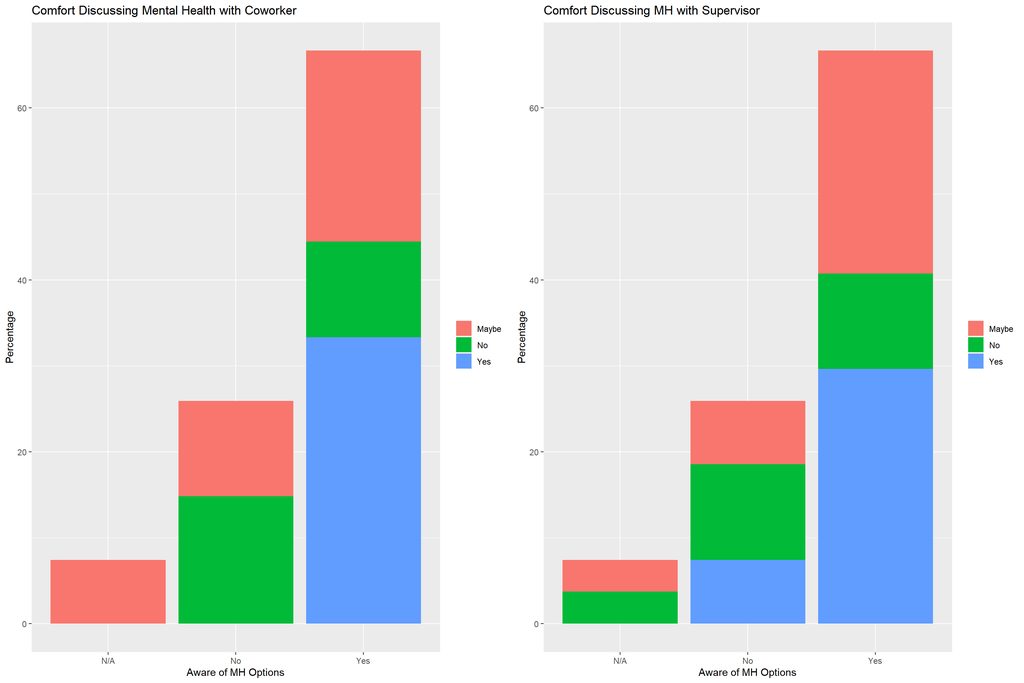

```r
grid.arrange(osmi_opt_com_cow,
             osmi_opt_sup,
             ncol = 2)
```

The data shows a similar pattern to that observed in Section 5.2.1. Respondents were more likely to be comfortable discussing mental health issues if they were aware of their mental healthcare options. Conversely, respondents who were not aware of their mental health options were less likely to be comfortable discussing mental health. Again, the “N/A” response was excluded for trend analysis and was simply provided for integrity’s sake.

### 5.2.3 Plotting Employer’s Active Involvment of Mental Health Awareness

The following variable “mh_employer_discuss” indicates whether the respondent’s employer has ever formally discussed mental health, such as via official communications or through mental wellness campaigns. Just like Section 5.2.1, we used the *factor* function to order the categorical responses in a hierarchical structure to help with trend analysis.

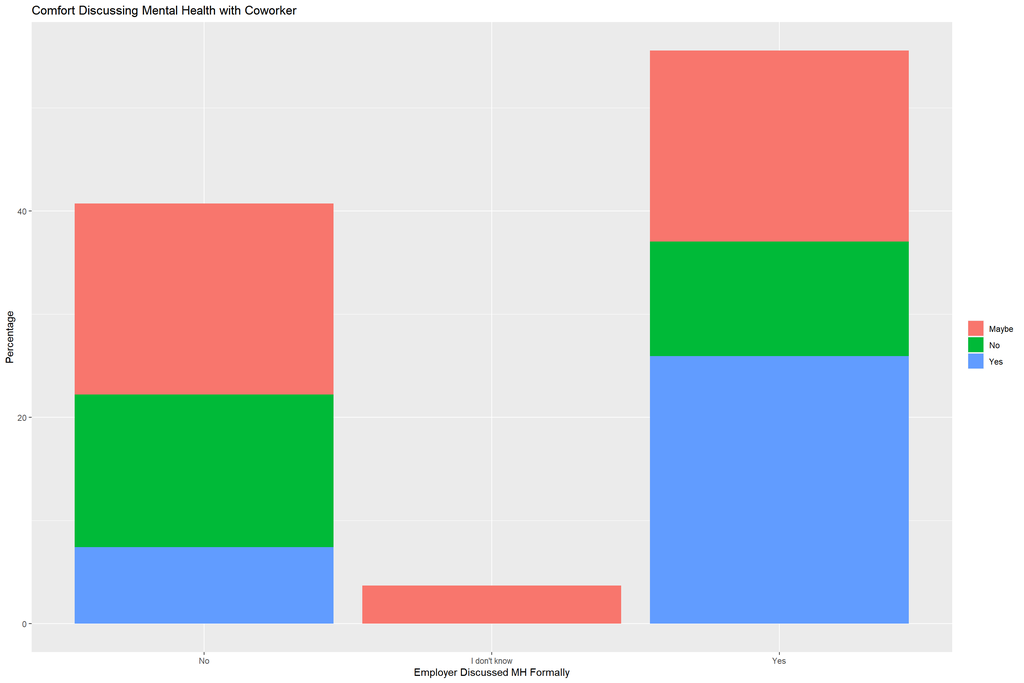

```r
osmi_comfort$mh_employer_discuss <- factor(osmi_comfort$mh_employer_discuss, order = TRUE,
                                           levels = c("No", "I don't know", "Yes"))

osmi_empdis_com_cow <- osmi_comfort %>%
  drop_na(mh_employer_discuss) %>%
  ggplot(aes(x = mh_employer_discuss, y = after_stat(100*count/sum(count)), fill = comfort_coworker)) +
  geom_bar() +
  labs(x = "Employer Discussed MH Formally", y = "Percentage", fill = "",
       title = "Comfort Discussing Mental Health with Coworker")
osmi_empdis_com_cow
```

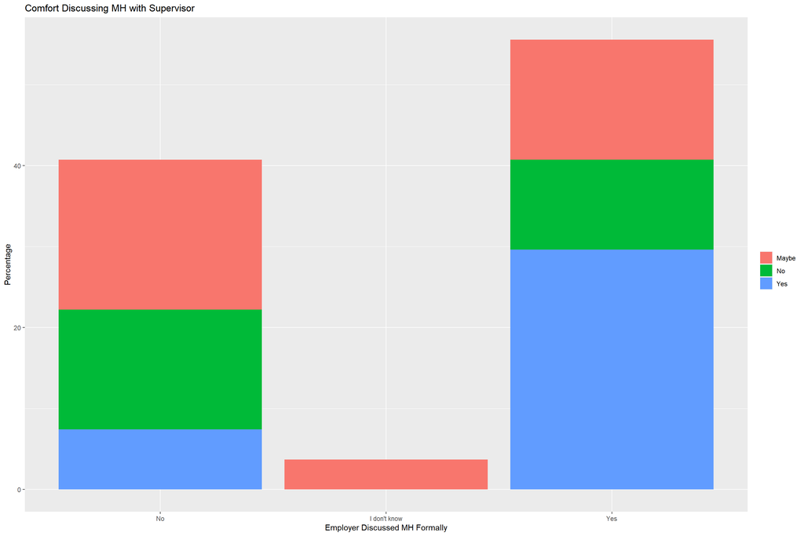

```r
osmi_empdis_sup <- osmi_comfort %>%
  drop_na(mh_employer_discuss) %>%
  ggplot(aes(x = mh_employer_discuss, y = after_stat(100*count/sum(count)), fill = comfort_supervisor)) +
  geom_bar() +
  labs(x = "Employer Discussed MH Formally", y = "Percentage", fill = "",
       title = "Comfort Discussing MH with Supervisor")
osmi_empdis_sup
```

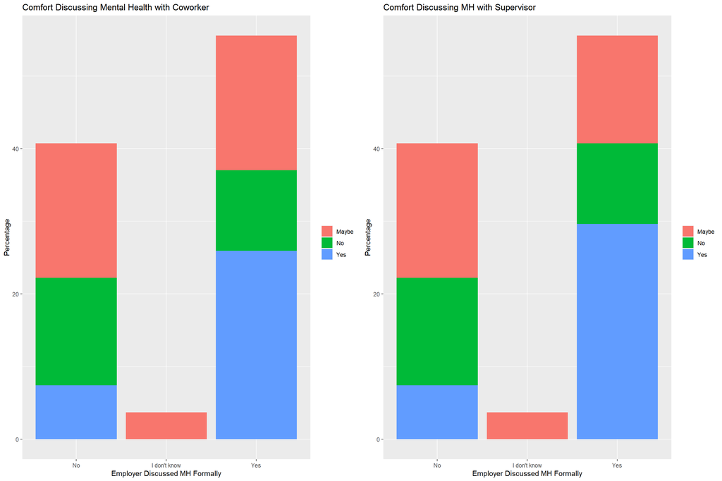

```r
grid.arrange(osmi_empdis_com_cow,
             osmi_empdis_sup,
             ncol = 2)
```

As with the previous Sections, respondents were more likely to be comfortable engaging in mental health topics with colleagues if their employer had formally brought up mental health at some point, and were less likely to be comfortable if their employer hadn’t discussed mental health formally before.

### 5.2.4 Plotting Employer Offering Mental Health Resources

The variable “mh_resource_employer_offer” indicates whether the respondent’s employer provides resources on learning more about mental health disorders and when to seek treatment. As with before, we use *factor* once again to order the categorical responses.

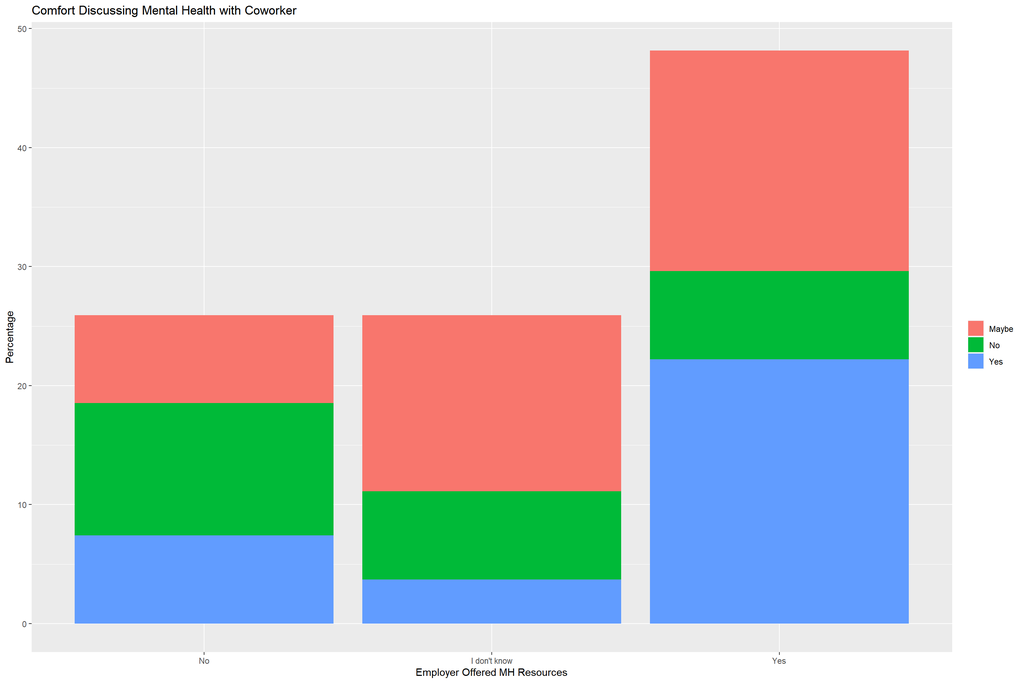

```r
osmi_comfort$mh_resource_employer_offer <- factor(osmi_comfort$mh_resource_employer_offer, order = TRUE,
                                           levels = c("No", "I don't know", "Yes"))

osmi_resoff_com_cow <- osmi_comfort %>%
  drop_na(mh_resource_employer_offer) %>%
  ggplot(aes(x = mh_resource_employer_offer, after_stat(100*count/sum(count)), fill = comfort_coworker)) +
  geom_bar() +
  labs(x = "Employer Offered MH Resources", y = "Percentage", fill = "",
       title = "Comfort Discussing Mental Health with Coworker")
osmi_resoff_com_cow
```

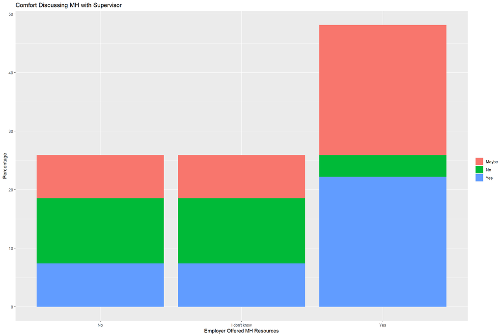

```r
osmi_resoff_sup <- osmi_comfort %>%
  drop_na(mh_resource_employer_offer) %>%
  ggplot(aes(x = mh_resource_employer_offer, y = after_stat(100*count/sum(count)), fill = comfort_supervisor)) +
  geom_bar() +
  labs(x = "Employer Offered MH Resources", y = "Percentage", fill = "",
       title = "Comfort Discussing MH with Supervisor")
osmi_resoff_sup
```

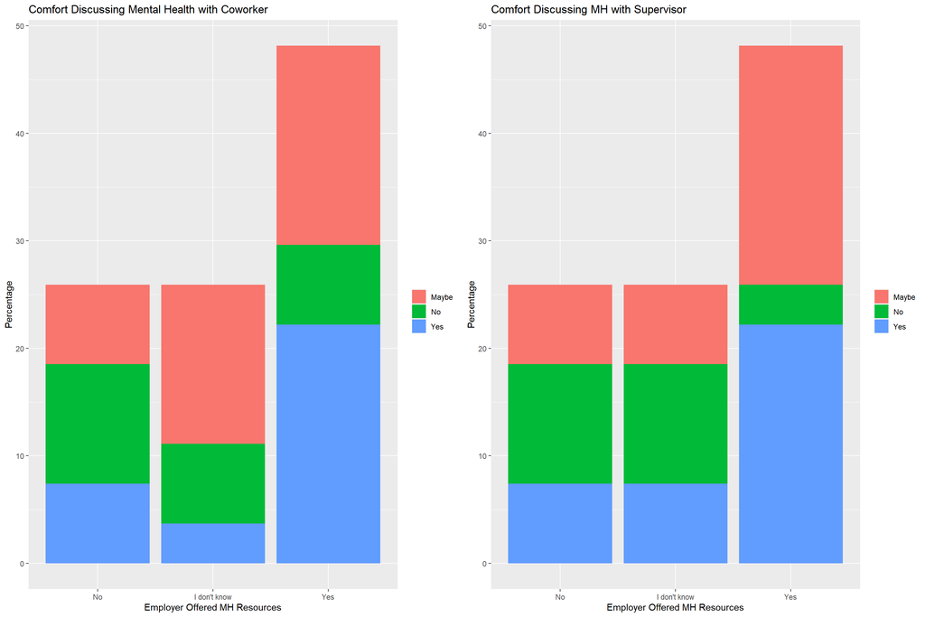

```r
grid.arrange(osmi_resoff_com_cow,
             osmi_resoff_sup,
             ncol = 2)
```

The resulting trend is similar to the previous Sections, although the difference in responses are not as drastic. Overall, respondents were more likely to be comfortable discussing mental health issues if their employer offered mental health resources, and were less likely to be comfortable doing so if their employer did not offer mental health resources. Respondents who did not know if such resources were offered were more likely to uncertain as to whether they would be comfortable engaging colleagues in mental health topics (accounting for over 50% of responses in the “I don’t know” group in the “Coworker” plot).